# PCIT-CoS-Waitlist RCT Paper 1: Parental Reflectiveness CCQE

Nancy Briggs

2024-06-18

### Parental Reflectiveness CCQE

Output run on 2024-06-18

Values are totals, not means, of the following CCQ variables: CCQE1, CCQE2, CCQE3, CCQE4_R, CCQE5, CCQE6, CCQE7, CCQE8, CCQE9_R, CCQE10, CCQE11, CCQE12, CCQE13, CCQE14_R, CCQE15, CCQE16, CCQE17, CCQE18

#### Descriptives

Raw Data

| group | time | n | mean | sd | median | min | max |
| --- | --- | --- | --- | --- | --- | --- | --- |
| 1 | 1 | 30 | 34.913 | 6.443 | 35.0 | 21 | 46 |
| 1 | 2 | 22 | 38.455 | 5.096 | 38.0 | 27 | 46 |
| 1 | 3 | 18 | 39.667 | 6.481 | 39.0 | 30 | 52 |
| 2 | 1 | 28 | 34.429 | 6.113 | 34.5 | 22 | 49 |
| 2 | 2 | 13 | 34.000 | 5.370 | 33.0 | 27 | 46 |
| 2 | 3 | 5 | 36.600 | 4.037 | 35.0 | 33 | 43 |
| 3 | 1 | 26 | 35.545 | 7.924 | 36.0 | 15 | 52 |
| 3 | 2 | 21 | 37.095 | 6.204 | 37.0 | 26 | 52 |
| 3 | 3 | 0 | NaN | NA | NA | Inf | -Inf |

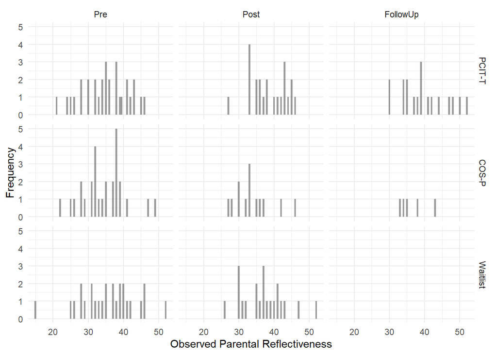

#### Model & Results

A linear mixed model with random effect for individual and fixed effects of group, time and the interaction was run on the raw data. Estimated marginal means were obtained, and contrasts specified to test Hypothesis 1 and Hypothesis 2.

```
## fixed-effect model matrix is rank deficient so dropping 1 column / coefficient
```

This is the ANOVA table for the model. p-values are likelihood ratio tests for adding the new term to the model just before. A p-value <0.05 indicates that adding that term results in better model fit. The most important p-value is the interaction p-value.

```
## refitting model(s) with ML (instead of REML)
```

|  | Effect | npar | AIC | BIC | logLik | deviance | Chisq | Df | Pr(>Chisq) |
| --- | --- | --- | --- | --- | --- | --- | --- | --- | --- |
| result0 | Intercept | 3 | 1052.442 | 1061.723 | -523.221 | 1046.442 | NA | NA | NA |
| result1 | Group | 5 | 1052.943 | 1068.411 | -521.471 | 1042.943 | 3.499 | 2 | 0.174 |
| result2 | Time | 7 | 1044.446 | 1066.102 | -515.223 | 1030.446 | 12.497 | 2 | 0.002 |
| result3 | Group*Time | 10 | 1044.182 | 1075.120 | -512.091 | 1024.182 | 6.264 | 3 | 0.099 |

Here, there is no evidence that the pattern of change over time is different between the groups (0.0995).

```
## Linear mixed model fit by REML. t-tests use Satterthwaite's method [
## lmerModLmerTest]
## Formula: outcome ~ group * time + (1 | id)
##    Data: dat
##
## REML criterion at convergence: 1005.5
##
## Scaled residuals:
##      Min       1Q   Median       3Q      Max
## -2.37446 -0.47095  0.00905  0.49829  2.40906
##
## Random effects:
##  Groups   Name        Variance Std.Dev.
##  id       (Intercept) 22.96    4.792
##  Residual             17.51    4.185
## Number of obs: 163, groups:  id, 85
##
## Fixed effects:
##              Estimate Std. Error       df t value Pr(>|t|)
## (Intercept)   34.9125     1.1615 114.7580  30.057  < 2e-16 ***
## group2        -0.4839     1.6717 114.7580  -0.289 0.772737
## group3         0.5129     1.6992 116.3750   0.302 0.763297
## time2          3.9248     1.2219  80.5400   3.212 0.001895 **
## time3          5.2486     1.3169  81.9386   3.985 0.000145 ***
## group2:time2  -4.4157     1.9685  86.9036  -2.243 0.027425 *
## group3:time2  -2.8595     1.7702  81.1810  -1.615 0.110110
## group2:time3  -3.9582     2.6555  88.6723  -1.491 0.139623
## ---
## Signif. codes:  0 '***' 0.001 '**' 0.01 '*' 0.05 '.' 0.1 ' ' 1
##
## Correlation of Fixed Effects:
##             (Intr) group2 group3 time2  time3  grp2:2 grp3:2
## group2      -0.695
## group3      -0.684  0.475
## time2       -0.411  0.286  0.281
## time3       -0.382  0.265  0.261  0.422
## group2:tim2  0.255 -0.367 -0.175 -0.621 -0.262
## group3:tim2  0.284 -0.197 -0.425 -0.690 -0.292  0.428
## group2:tim3  0.189 -0.272 -0.129 -0.209 -0.496  0.328  0.145
## fit warnings:
## fixed-effect model matrix is rank deficient so dropping 1 column / coefficient
```

#### Estimated Means & Change

Estimated means for each Treatment and Time are presented. In addition, within-group change between time points is presented with 95% CIs.

##### Group mean difference at each timepoint

NOTE THIS SET OF RESULTS DOES NOT BOOTSTRAP.

Effect sizes all calculated by the pooled T1 SD of the outcome. Adjusted p-value from Bonferroni correction.

Group Differences at Each Time Point

| Group Difference | Time | Mean | SE | t | p | adj p | Lower CL | Upper CL | Effect Size | Lower CL | Upper CL |
| --- | --- | --- | --- | --- | --- | --- | --- | --- | --- | --- | --- |
| 1 - 2 | 1 | 0.484 | 1.672 | 0.289 | 0.955 | 1.000 | -3.485 | 4.453 | 0.077 | -0.137 | 0.581 |
| 1 - 3 | 1 | -0.513 | 1.699 | -0.302 | 0.951 | 1.000 | -4.547 | 3.521 | -0.082 | -0.339 | 0.138 |
| 2 - 3 | 1 | -0.997 | 1.728 | -0.577 | 0.833 | 1.000 | -5.098 | 3.104 | -0.159 | -0.677 | 0.222 |
| 1 - 2 | 2 | 4.900 | 2.068 | 2.369 | 0.050 | 0.057 | 0.003 | 9.796 | 0.779 | 0.414 | 1.309 |
| 1 - 3 | 2 | 2.347 | 1.865 | 1.259 | 0.421 | 0.631 | -2.072 | 6.765 | 0.373 | 0.065 | 0.795 |
| 2 - 3 | 2 | -2.553 | 2.096 | -1.218 | 0.444 | 0.675 | -7.515 | 2.409 | -0.406 | -0.740 | 0.050 |
| 1 - 2 | 3 | 4.442 | 2.737 | 1.623 | 0.239 | 0.320 | -2.039 | 10.923 | 0.707 | 0.097 | 1.285 |
| 1 - 3 | 3 | NA | NA | NA | NA | NA | NA | NA | NA | NA | NA |
| 2 - 3 | 3 | NA | NA | NA | NA | NA | NA | NA | NA | NA | NA |

##### Change within each group

Within-Group Change and Effect Sizes

| Change | Group | Mean | SE | t | p | adj p | Lower CL | Upper CL | Effect Size | Lower CL | Upper CL |
| --- | --- | --- | --- | --- | --- | --- | --- | --- | --- | --- | --- |
| 1 - 2 | 1 | -3.925 | 1.224 | -3.206 | 0.005 | 0.006 | -6.847 | -1.002 | -0.624 | -0.836 | -0.394 |
| 1 - 3 | 1 | -5.249 | 1.320 | -3.976 | 0.000 | 0.000 | -8.399 | -2.098 | -0.835 | -1.136 | -0.538 |
| 2 - 3 | 1 | -1.324 | 1.368 | -0.968 | 0.599 | 1.000 | -4.593 | 1.946 | -0.211 | -0.507 | -0.113 |
| 1 - 2 | 2 | 0.491 | 1.550 | 0.317 | 0.946 | 1.000 | -3.202 | 4.184 | 0.078 | -0.229 | 0.409 |
| 1 - 3 | 2 | -1.290 | 2.318 | -0.557 | 0.843 | 1.000 | -6.812 | 4.231 | -0.205 | -1.042 | 0.507 |
| 2 - 3 | 2 | -1.781 | 2.380 | -0.749 | 0.735 | 1.000 | -7.460 | 3.897 | -0.283 | -1.042 | 0.491 |
| 1 - 2 | 3 | -1.065 | 1.284 | -0.830 | 0.686 | 1.000 | -4.129 | 1.998 | -0.169 | -0.304 | 0.256 |
| 1 - 3 | 3 | NA | NA | NA | NA | NA | NA | NA | NA | NA | NA |
| 2 - 3 | 3 | NA | NA | NA | NA | NA | NA | NA | NA | NA | NA |

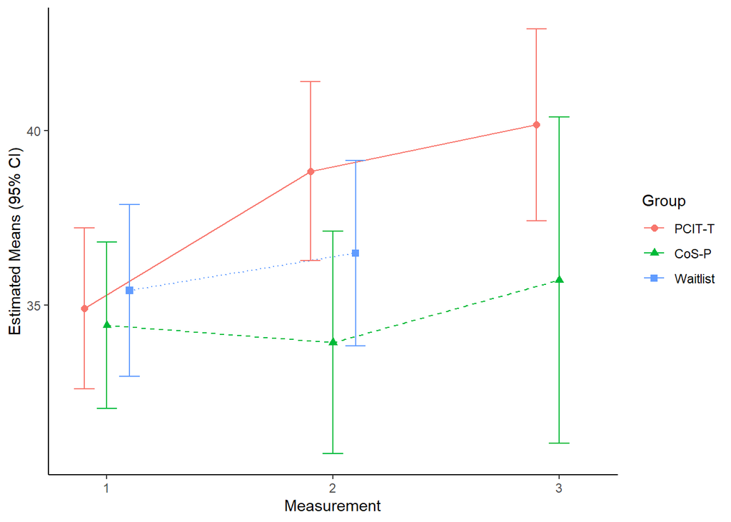

#### Hypothesis 1

We hypothesize that from baseline (‘T1’) to post-treatment/waitlist (‘T2’) there will be a gradient effect, whereby parent-child dyads who receive PCIT-T will show the greatest gains and parent-child dyads who receive no treatment will show the least gains. For the outcome, then, the null hypothesis is:

$H_0: \text {mean change}(\text{PCIT-T}) = \text {mean change}(\text{CoS-P}) = \text {mean change}(\text{Waitlist})$ $H_A: \text {mean change}(\text{PCIT-T}) > \text {mean change}(\text{CoS-P}) > \text {mean change}(\text{Waitlist})$

This is a joint hypothesis test.

First, confirming that the ordering of the means is as hypothesized:

```
## group = 1:
##  contrast estimate   SE   df t.ratio p.value
##  1 - 2      -3.925 1.22 81.5  -3.206  0.0054
##  1 - 3      -5.249 1.32 82.9  -3.976  0.0004
##  2 - 3      -1.324 1.37 77.8  -0.968  0.5995
##
## group = 2:
##  contrast estimate   SE   df t.ratio p.value
##  1 - 2       0.491 1.55 92.0   0.317  0.9463
##  1 - 3      -1.290 2.32 91.9  -0.557  0.8432
##  2 - 3      -1.781 2.38 83.1  -0.749  0.7353
##
## group = 3:
##  contrast estimate   SE   df t.ratio p.value
##  1 - 2      -1.065 1.28 82.7  -0.830  0.6856
##  1 - 3      nonEst   NA   NA      NA      NA
##  2 - 3      nonEst   NA   NA      NA      NA
##
## Degrees-of-freedom method: kenward-roger
## P value adjustment: tukey method for comparing a family of 3 estimates
```

| contrast | group | t1t2change | quality | p.value |
| --- | --- | --- | --- | --- |
| 1 - 2 | 1 | 3.925 | increase t1 to t2 | 0.005 |
| 1 - 2 | 2 | -0.491 | decreased t1 to t2 | 0.946 |
| 1 - 2 | 3 | 1.065 | increase t1 to t2 | 0.686 |

Is the ordering of change satisfied?

Greatest to least change from t1 to t2: Order not satisfied

Note that I interpreted an increase in scores as being “better”. If a decrease in scores is “better” then these change values should be interpreted in that light.

```
##   (Intercept) group2 group3 time2 time3 group2:time2 group3:time2 group2:time3
## 1           0      0      0     0     0            1            0            0
## 2           0      0      0     0     0           -1            1            0
```

```
##
##   General Linear Hypotheses
##
## Linear Hypotheses:
##        Estimate
## 1 == 0   -4.416
## 2 == 0    1.556
##
## Global Test:
##       F DF1 DF2  Pr(>F)
## 1 2.778   2 153 0.06529
```

p= 0.065. We have no evidence that there is a difference in the change over from Baseline to Post amongst the groups.

#### Hypothesis 2

There will be a gradient of size of change from T2 to T3 such that the change in the PCIT-T group > the change in the CoS-P group. This isn’t really a gradient; it’s just 1 hypothesis.

First, the change in PCITT and COSP from time 2 to time 3:

| contrast | group | t2t3change | quality | p.value |
| --- | --- | --- | --- | --- |
| 2 - 3 | 1 | 1.324 | increase t2 to t3 | 0.599 |
| 2 - 3 | 2 | 1.781 | increase t2 to t3 | 0.735 |
| 2 - 3 | 3 | NA | NA | NA |

Assuming an increase in scores is better, PCITT < COS-P, increase was not greater in PCITT

Assuming a decrease in scores is better,PCITT < COS-P, decrease was not greater in PCITT

```
##
##   Simultaneous Tests for General Linear Hypotheses
##
## Fit: lmer(formula = outcome ~ group * time + (1 | id), data = dat)
##
## Linear Hypotheses:
##        Estimate Std. Error z value Pr(>|z|)
## 1 == 0   0.4575     2.7381   0.167    0.867
## (Adjusted p values reported -- single-step method)
```

p=0.867, so we have no evidence to suggest that the change from t2 to t3 in PCITT is greater than the change in COSP.

##### Change from T1-T3

```
##
##   General Linear Hypotheses
##
## Linear Hypotheses:
##        Estimate
## 1 == 0   -3.958
##
## Global Test:
##       F DF1 DF2 Pr(>F)
## 1 2.222   1 153 0.1381
```

p=0.1381. We have no evidence that the change from T1 to T3 is different for G1 and G2

#### Residuals

Assumptions of the model are met.

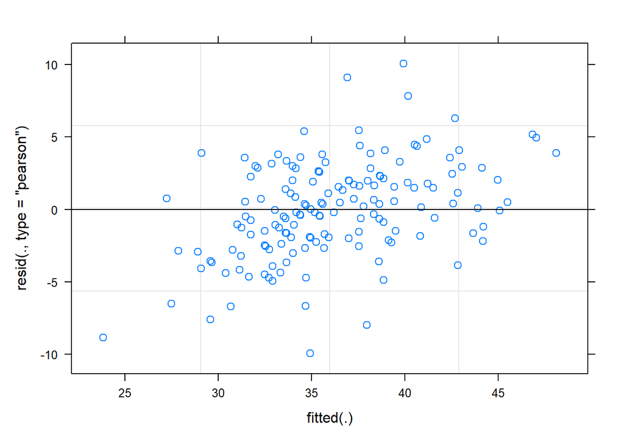

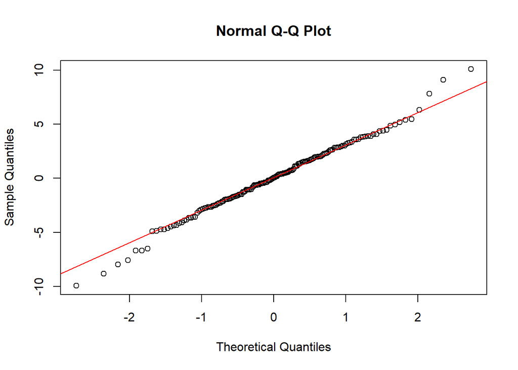

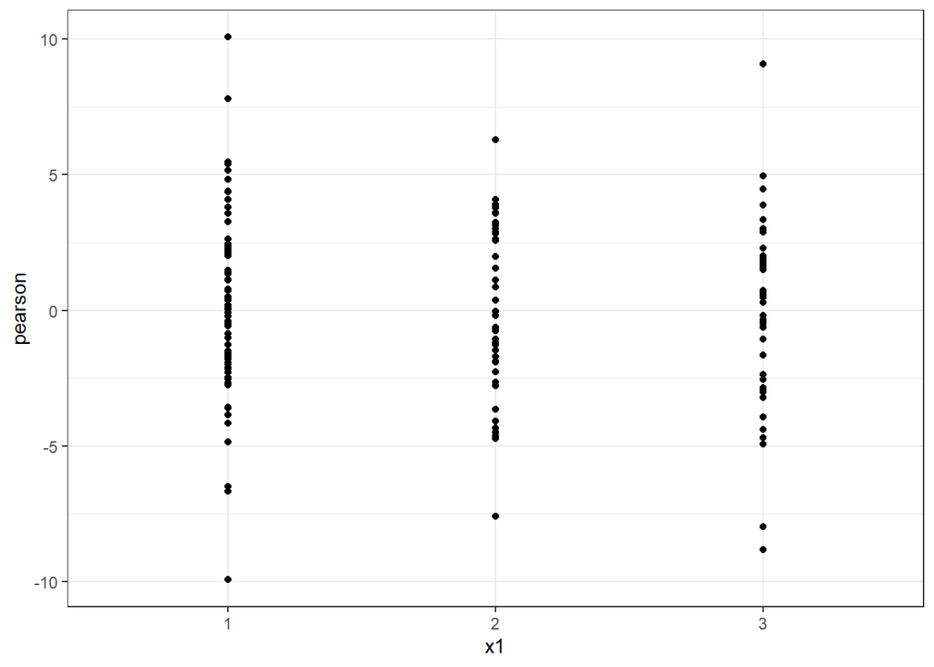

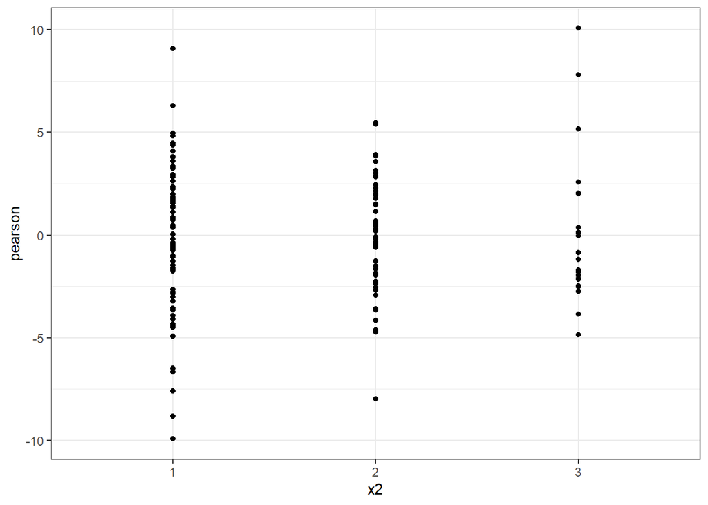